# Alternatives to ggmap for beautiful maps

Jacqueline Araya

6/16/2020

With the recent changes to Google API, the `ggmap` library is no longer totally free to use (you can read more about it [here](https://cran.r-project.org/web/packages/ggmap/readme/README.html)). I was wondering what other alternatives there are in R to make not only beautiful, but useful maps with all the `ggplot` machinery at your hands.

Although, the new API charges may not be pricey for moderate use, if you use `ggmap` sparingly, like me, the service might just not be worthy. So, what other R resources are out there?

1. The old but trusted shape file
2. `ggmap` with Open Source maps

Let’s get some datasets with location data and make some maps!

## Load libraries

```r
library(ggplot2)
library(sf)
library(ggmap)
library(tidyr)
library(dplyr)
```

## Load and Read Datasets

I’ve chosen to plot the recently added open datasets of the state of Vermont, particularly of its most populous city, [Burlington](https://en.wikipedia.org/wiki/Burlington,_Vermont). You can find these and other interesting datasets in the city’s new portal of Open Data [here](https://data.burlingtonvt.gov/pages/home/).

I picked the “Tree Database” which contains all trees currently managed by the city, and the schools (public and private) data set along with the childcare sites around the city.

```r
#trees dataset
trees = read.csv("planting-sites.csv", sep=";")
#public schools dataset
schools = read.csv("us-public-schools.csv", sep=";")
#private schools dataset
schools_private = read.csv("us-private-schools.csv", sep=";")
#child care dataset
childcare = read.csv("child-care-locations.csv", sep = ";")
```

## Preprocess the data

We need to get the data ready before anything else, so here I do some processing of the data, specifically:

- Split the `Geo.Point` column into two separates columns of latitude and longitude for each data set and change its type to numeric variables.
- Filter schools for the city of Burlington.
- We will use the column `Enrollment` of schools to plot schools by size

```r
trees = trees %>%
  separate(Geo.Point, c("lat","long"), ",")

trees = trees %>%
  mutate(lat = as.numeric(lat),
         long = as.numeric(long))


bt_schools = schools %>%
  separate(Geo.Point, c("lat","long"), ",")

bt_schools = bt_schools %>%
  mutate(lat = as.numeric(lat),
         long = as.numeric(long),
         Enrollment = as.numeric(Enrollment))

#filter schools only for burlington with greater than zero enrollment
bt_schools = bt_schools %>%
  filter(City %in% c("BURLINGTON") & Enrollment>0)


bt_schools_private = schools_private %>%
  separate(Geo.Point, c("lat","long"), ",")

bt_schools_private = bt_schools_private %>%
  rename(Enrollment = ENROLLMENT ) %>%
  mutate(lat = as.numeric(lat),
         long = as.numeric(long),
         Enrollment = as.numeric(Enrollment))

#filter private schools only for burlington
bt_schools_private = bt_schools_private %>%
  filter(CITY %in% c("BURLINGTON") & Enrollment>0)


childcare = childcare %>%
  separate(geo_point, c("lat","long"), ",")

childcare = childcare %>%
  mutate(lat = as.numeric(lat),
         long = as.numeric(long)) %>%
  filter(lat>44)
```

## Subsetting

Lastly, we are going to modify the dataframes, by selecting the relevant columns and creating two new ones: `type` and `point_size` to differentiate points when we plot them.

```r
sb_trees = trees %>%
  select(long, lat) %>%
  mutate(type = "Trees",
         point_size = "small")

sb_schools = bt_schools %>%
  select(long,lat, Enrollment) %>%
  mutate(type = "Public schools",
         point_size = Enrollment)

sb_schools_priv = bt_schools_private %>%
  select(long,lat, Enrollment) %>%
  mutate(type = "Private schools",
         point_size = Enrollment)

sb_childcare = childcare %>%
  select(long,lat) %>%
  mutate(type = "Child Care",
         point_size = "small")
```

# Option 1: get your shape file

To make this option works, we first need to get our hands on a shape file of the location we are trying to map. I found this to be fairly easy, specially for major cities. There are a bunch of shape files available online, like this [US states map](https://www.arcgis.com/home/item.html?id=f7f805eb65eb4ab787a0a3e1116ca7e5). Here, you need to decide what type of location granularity you want to display your data on, it can be from a broader perspective such as states, or a very fine division such as districts or counties. So you need to look for your shape file accordingly.

I got Burlington city wards and districts [shape file](https://data.burlingtonvt.gov/explore/dataset/city-wards-and-districts/information/?disjunctive.ward&location=12,44.48247,-73.18251&basemap=jawg.streets) from the same Open Data Portal of the city.

## Get Shape file

From here on, we’ll make use of the library [`sf`](https://cran.r-project.org/web/packages/sf/sf.pdf) (special features) to work easily with *spatial* data but maintaining the same logic of layers in a plot when working with `ggplot`.

Once you have your shape file, we are going to read it using the `st_read` function from `sf` library. It will display the geometry information of the shape file.

```r
bt_shape = st_read("./city-wards-and-districts/city-wards-and-districts.shp")
```

## Create Sf datasets

Now, we need to transform our dataframes to an `sf` object. What this basically do is take the columns with coordinates, such as longitude and latitude, and convert them into a geometry column, we’ll use the `st_as_sf` function.

```r
trees_sf = st_as_sf(sb_trees, coords = c("long","lat"), remove = FALSE, crs = 4326, agr ="constant")

bt_schools_sf = st_as_sf(sb_schools, coords = c("long","lat"), remove = FALSE, crs = 4326, agr ="constant")

bt_schools_priv_sf = st_as_sf(sb_schools_priv, coords = c("long","lat"), remove = FALSE, crs = 4326, agr ="constant")

childcare_sf = st_as_sf(sb_childcare, coords = c("long","lat"), remove = FALSE, crs = 4326, agr ="constant")
```

## Let’s plot!

If you are familiar with `ggplot`, this is very straightforward, but instead of the usual `ggplot` layers such as `geom_point`, we’ll use the function `geom_sf` to display our data based on location.

I first started adding the shape file layer to then add the trees, schools and childcare points as we need to, with the same function. With a tweak in colors, sizes and other options, we can get a simple yet informative map fairly quickly:

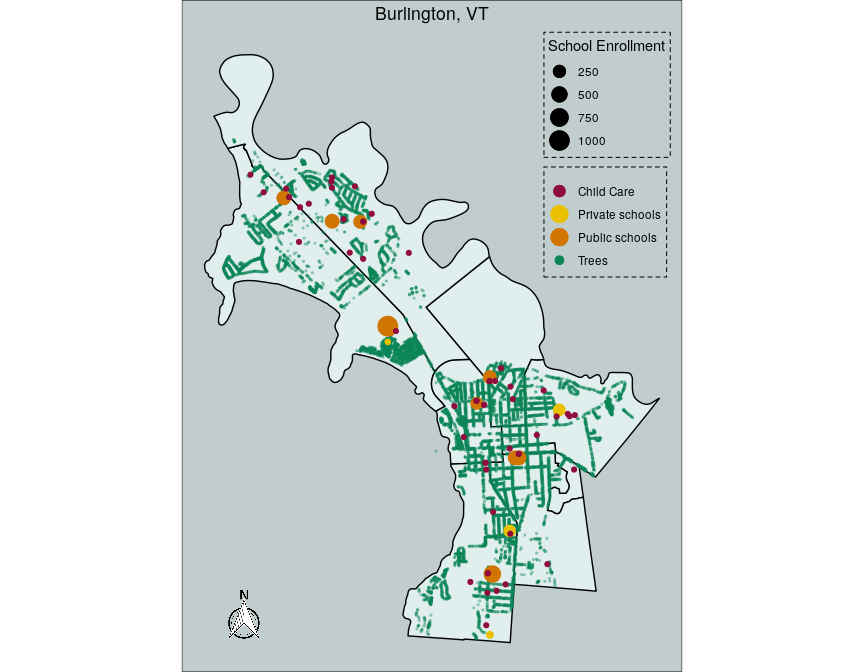

```r
ggplot() +
  geom_sf(data = bt_shape, size = 0.5, color = "black", fill = "azure2") +
  geom_sf(data = trees_sf, aes(color = type, alpha = type),
          size = 0.5, show.legend = "point") +
  geom_sf(data = bt_schools_sf, aes(color = type, size = point_size, alpha = type),
          stroke=1, show.legend = "point") +
  geom_sf(data = bt_schools_priv_sf, aes(color = type, size = point_size, alpha = type),
          stroke=1, show.legend = "point") +
  geom_sf(data = childcare_sf, aes(color = type, alpha = type),
          size = 1.5, show.legend = "point") +
  scale_color_manual(name = "", values = c("#900c3f","#eac100","#cf7500","#0b8457")) + #childcare, public, private, trees
  scale_alpha_manual(guide = 'none', values = c(1, 1, 1,0.3)) +
  scale_size(name = "School Enrollment") +
  ggtitle("Burlington, VT") +
  guides(color = guide_legend(title = NULL, override.aes = list(size = c(3,5,5,2)))) +
  theme_void() +
  theme(plot.background = element_rect(fill = "azure3"),
        legend.position = c(0.85, 0.8),
        plot.title = element_text(hjust = 0.5),
        legend.background = element_rect(fill = "azure3", color = "black", linetype = "dashed"),
        legend.margin = margin(4, 4, 4, 3, "pt")) +
  coord_sf() +
  ggsn::north(trees_sf, location = "bottomleft")
```

# Option 2: Open source maps

Here, things are a little bit different. First, we’ll get an Open Source map from either *StatenMaps* or *OpenStreetMaps*, using the same function for Google maps, `get_map` from the `ggmap` library.

Here is when it can get a little bit hard, you need to know the limits of the map you are trying to fetch. Think of a square, basically the `x` and `y` coordinates of your location such as `xmin = left`, `xmax = right`, `ymin = bottom` and `ymax = top`. I knew these values from just looking at my shape file, so that’s one very easy way to do it, other way could be to head to Google maps and look for the place you are trying to map and get the coordinates approximately. Then, you can calibrate as you see the map you are getting.

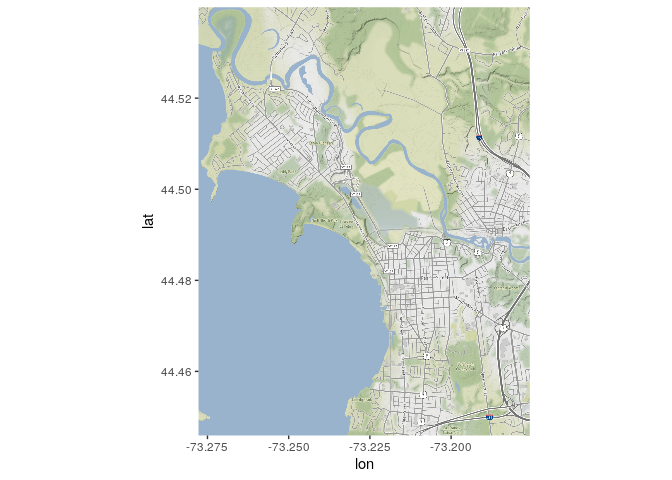

```r
bbox = c(left = -73.27776, bottom = 44.44592, right = -73.1758, top = 44.53994)

p = get_map(bbox, zoom=14, source = "osm", maptype = "roadmap")

ggmap(p)
```

Once you get the right map, just pass it as input to the `ggmap` function and then create your map with the `ggplot` machinery. We are using the same points as before, but using the `geom_point` function to add them as layers to the `ggmap` object.

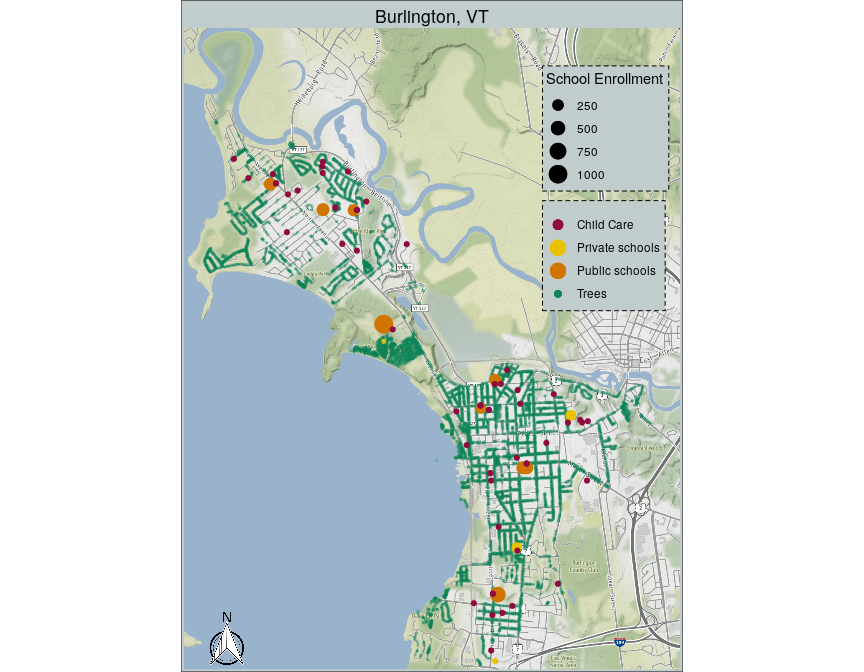

```r
ggmap(p) +
  geom_point(data = sb_trees, aes(long, lat, color = type, alpha = type), size= 0.5) +
  geom_point(data = sb_schools, aes(long, lat, color = type, alpha = type, size = point_size)) +
  geom_point(data = sb_schools_priv, aes(long, lat, color = type, alpha = type, size = point_size)) +
  geom_point(data = sb_childcare, aes(long, lat, color = type, alpha = type), size= 1.5) +
  scale_color_manual(name = "", values = c("#900c3f","#eac100","#cf7500","#0b8457")) + #childcare, public, private, trees
  scale_alpha_manual(guide = 'none', values = c(1, 1, 1, 0.2)) +
  scale_size(name = "School Enrollment") +
  ggtitle("Burlington, VT") +
  guides(color = guide_legend(title = NULL, override.aes = list(size = c(3,5,5,2)))) +
  theme_void() +
  theme(plot.background = element_rect(fill = "azure3"),
        legend.position = c(0.85, 0.75),
        legend.background = element_rect(fill = "azure3", color = "black", linetype = "dashed"),
        legend.margin = margin(4, 4, 4, 3, "pt"),
        plot.title = element_text(hjust = 0.5),
        plot.margin = margin(2, 2, 2, 2, "pt")) +
  coord_quickmap() +
  ggsn::north(sb_trees, location = "bottomleft")
```

and voilà!

Finally, a nice thing to add to any map are the classic scale symbols, such as north and kms/miles scale. You can do this with the `ggsn` library with the `north` method. A warning when you use this with `ggmap` objects, you would need to add a coordinate system to the object for it to know where it should be placed. I found that `coord_quickmap` does the trick.